# Practice-Location Specificity, Spatial Concordance, and Longitudinal Directory Audits

## The scenario that starts every one of these sections

Your team links NPPES to Medicare PECOS through organizational group reassignments and reports that 54% of nurse-midwives have no valid practice address on file. Three weeks later a different analyst reruns the same join and gets 4%. Nobody touched the underlying data. The number moved because of a plumbing decision nobody wrote down: whether a clinician’s address counts as “missing” when it can only be recovered by following her employer’s billing group through a 20-site reassignment chain.

That is the failure mode behind every section below. Directory audits rarely break because two sources disagree – sources always disagree a little. They break because of invisible pipeline choices: a relational join that silently multiplies one clinician into thirteen suites across two states, a sub-feed that goes missing for exactly one panel year and reads as a mass exodus, two competing definitions of “100%” that both sound authoritative in print, or a three-way tie vote that abstains when coarser evidence could have resolved it outright. Each mistake is cheap to make and expensive to defend to a reviewer, an IRB, or the HHS Office of Inspector General.

This vignette fixes eight of them, one function at a time, each with real numbers from a toy cohort you can trace end to end:

| # | The trap | The fix |
| --- | --- | --- |
| 1 | `"7030"` and `"07030"` read as a mismatch when they’re the same ZIP code | `normalize_directory_attribute()` – canonical format guards for 7 directory field types |
| 2 | A missing sub-feed for one year looks like 35% of clinicians vanished | `attribute_source_vintage_audit()` – decomposes composite sources by sub-feed |
| 3 | A billing-group join turns one clinician into 13 suites in 2 states | `attribute_enrollment_cardinality_audit()`, `attribute_location_specificity()`, `attribute_billing_group_topology()` |
| 4 | Overlapping ZIP5/SCF3/mailing match rates sum to more than 100% | `attribute_geographic_concordance()`, `attribute_spatial_distance()` – mutually exclusive bands, continuous distance |
| 5 | A 3-way tie at ZIP5 abstains when the state and 3-digit area agree | `attribute_inconsistency_table()`, `attribute_hierarchical_truth_fusion()` – coarse-to-fine consensus |
| 6 | “She moved” could mean relocated for good or commutes across a bridge | `attribute_disagreement_trajectories()`, `attribute_mover_stayer_transition_matrix()` |
| 7 | A retired license reads identically to a dead NPI unless you check both | `attribute_enumeration_lifecycle()`, `design_verification_sample()` |
| 8 | A manuscript number quietly changes between drafts with no paper trail | `attribute_oig_audit_prose()`, `attribute_oig_audit_html()`, `attribute_audit_diff()` |

## Attribute Normalization and Format-Validity Guards

**The trap:** two directories can report the exact same ZIP code, phone number, or credential and still look like a disagreement, because one of them dropped a leading zero, formatted a phone number with dashes instead of parentheses, or spelled out “Certified Nurse Midwife” while the other wrote “CNM.” Every downstream comparison in this package inherits that noise unless it’s cleaned first.

**The fix:** `attribute_record_presence()` already distinguishes whether a field is `"populated"` from whether it’s well-formed. `normalize_directory_attribute()` goes one step further and runs canonical normalizers across all seven standard directory data types – restoring stripped leading zeros on 3- and 4-digit Northeast and Puerto Rico ZIP codes (`"7030"` $\to$ `"07030"`, `"901"` $\to$ `"00901"`), validating 10-digit NANP phone numbers, and verifying the ISO/CMS Luhn check digit on 10-digit NPIs:

```r
# 5-digit ZIP normalization with leading-zero restoration and placeholder rejection
normalize_directory_attribute(
  c("80204-1234", "7030", "901", "00000", "ZIP IS UNKNOWN", NA),
  normalizer = "zip5"
)
```

```
#> # A tibble: 6 × 5
#>   raw_value      populated normalized_value format_valid validation_status
#>   <chr>          <lgl>     <chr>            <lgl>        <chr>
#> 1 80204-1234     TRUE      80204            TRUE         valid
#> 2 7030           TRUE      07030            TRUE         valid
#> 3 901            TRUE      00901            TRUE         valid
#> 4 00000          TRUE      <NA>             FALSE        invalid_zip5
#> 5 ZIP IS UNKNOWN TRUE      <NA>             FALSE        invalid_zip5
#> 6 <NA>           FALSE     <NA>             FALSE        missing_or_blank
```

```r
# 10-digit NANP telephone normalization
normalize_directory_attribute(
  c("(303) 555-0199", "1-303-555-0199", "000-000-0000", "9999999999"),
  normalizer = "phone10"
)
```

```
#> # A tibble: 4 × 5
#>   raw_value      populated normalized_value format_valid validation_status
#>   <chr>          <lgl>     <chr>            <lgl>        <chr>
#> 1 (303) 555-0199 TRUE      3035550199       TRUE         valid
#> 2 1-303-555-0199 TRUE      3035550199       TRUE         valid
#> 3 000-000-0000   TRUE      <NA>             FALSE        invalid_phone10
#> 4 9999999999     TRUE      <NA>             FALSE        invalid_phone10
```

```r
# Credential token canonicalization and 10-digit NPI Luhn check
normalize_directory_attribute(
  c("C.N.M., M.S.N., APRN", "RN, CNM", "---"),
  normalizer = "credential_token"
)
```

[output not shown]

```r
normalize_directory_attribute(
  c("1234567893", "1234567890", "ABC"),
  normalizer = "npi10"
)
```

```
#> # A tibble: 3 × 5
#>   raw_value  populated normalized_value format_valid validation_status
#>   <chr>      <lgl>     <chr>            <lgl>        <chr>
#> 1 1234567893 TRUE      1234567893       TRUE         valid
#> 2 1234567890 TRUE      <NA>             FALSE        invalid_npi_luhn
#> 3 ABC        TRUE      <NA>             FALSE        invalid_npi_luhn
```

**Why it matters:** every section after this one compares values across sources. If the comparison runs on un-normalized strings, “disagreement” partly just means “different formatting conventions” – and that inflates every inconsistency rate downstream, including the headline numbers reconciled at the very end of this vignette.

## Auditing Longitudinal Source Coverage for Sub-Feed Discontinuities

**The trap:** longitudinal source families are often stitched together from sub-feeds with their own, independent refresh schedules – historic Medicare `PECOS` enrollment extracts alongside `Doctors and Clinicians` (`DAC`) Care Compare snapshots, for instance. If one sub-feed is simply *absent* for a single panel year, the combined coverage rate craters for that year alone, and a careless read says “35% of clinicians left the workforce in 2020” when in fact a vendor just skipped a refresh.

**The fix:** `attribute_source_vintage_audit()` decomposes composite families by sub-feed and flags year-over-year percentage-point jumps (`abs(yoy_pp_change) >= jump_threshold_pct`) together with exactly which sub-feed went missing:

```r
cohort_pop <- expand.grid(
  npi = sprintf("NPI%02d", 1:20),
  year = 2018:2021,
  stringsAsFactors = FALSE
)

# PECOS is present in 2018, 2019, and 2021, but omitted in 2020
pecos_subfeed <- data.frame(
  npi = c(sprintf("NPI%02d", 1:11), sprintf("NPI%02d", 1:12), sprintf("NPI%02d", 1:13)),
  year = c(rep(2018L, 11), rep(2019L, 12), rep(2021L, 13))
)

# DAC is present in all four years (covering 5 clinicians per year)
dac_subfeed <- data.frame(
  npi = rep(sprintf("NPI%02d", 1:5), 4),
  year = rep(2018:2021, each = 5)
)

nppes_feed <- cohort_pop

vintage_res <- attribute_source_vintage_audit(
  population = cohort_pop,
  sources = list(pecos = pecos_subfeed, dac = dac_subfeed, nppes = nppes_feed),
  source_families = list(medicare_combined = c("pecos", "dac")),
  jump_threshold_pct = 15.0
)

vintage_res$family_decomposition[, c(
  "family", "year", "n_combined", "pct_combined",
  "yoy_pp_change", "active_subfeeds", "missing_subfeeds", "vintage_status"
)]
```

```
#> # A tibble: 4 × 8
#>   family             year n_combined pct_combined yoy_pp_change active_subfeeds
#>   <chr>             <int>      <int>        <dbl>         <dbl> <chr>
#> 1 medicare_combined  2018         11           55            NA pecos+dac
#> 2 medicare_combined  2019         12           60             5 pecos+dac
#> 3 medicare_combined  2020          5           25           -35 dac
#> 4 medicare_combined  2021         13           65            40 pecos+dac
#>   missing_subfeeds vintage_status
#>   <chr>            <chr>
#> 1 none             complete_subfeeds
#> 2 none             complete_subfeeds
#> 3 pecos            partial_subfeed_omission
#> 4 none             complete_subfeeds
```

```r
vintage_res$flagged_discontinuities[, c(
  "source", "year", "pct_present", "yoy_pp_change",
  "discontinuity_flag", "missing_subfeeds"
)]
```

[output not shown]

### Figure 1: a missing sub-feed looks exactly like a mass exodus

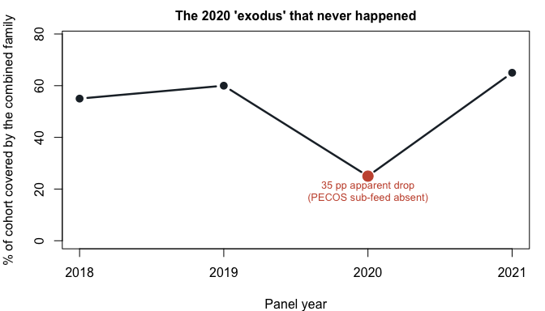

```r
fam <- vintage_res$family_decomposition[vintage_res$family_decomposition$family == "medicare_combined", ]
fam <- fam[order(fam$year), ]

op <- par(mar = c(4, 4, 2, 1))
plot(fam$year, fam$pct_combined, type = "b", pch = 19, lwd = 2.5, col = "#1F2A33",
     ylim = c(0, max(fam$pct_combined) * 1.2), xaxt = "n",
     xlab = "Panel year", ylab = "% of cohort covered by the combined family",
     main = "The 2020 'exodus' that never happened", cex.main = 1)
axis(1, at = fam$year)
dip <- which.min(fam$pct_combined)
points(fam$year[dip], fam$pct_combined[dip], pch = 19, cex = 1.8, col = "#C8553D")
text(fam$year[dip], fam$pct_combined[dip],
     labels = paste0(abs(round(fam$yoy_pp_change[dip], 1)), " pp apparent drop\n(PECOS sub-feed absent)"),
     pos = 1, cex = 0.8, col = "#C8553D")
```

```r
par(op)
```

**Why it matters:** without this decomposition, 2020 reads as a genuine collapse in workforce participation. With it, the drop is correctly attributed to one sub-feed’s refresh schedule – a one-sentence footnote instead of a false headline finding. This exact scenario resurfaces later as a line item in the audit reconciliation log, near the end of this vignette.

## Enrollment Cardinality, Location Specificity, and Billing-Group Topology

**The trap:** in Medicare `PECOS`, most nurse-midwives and allied clinicians don’t carry a practice address on their own enrollment record at all – instead, they reassign benefits to an organization, and that organization carries the addresses. Following the reassignment link recovers locations for nearly the whole cohort, but it also means a clinician whose hospital system operates a Wyoming clinic she has never set foot in now shows up *linked* to Cheyenne, Wyoming. A single relational join can turn one clinician into thirteen suites spanning two states, and nothing about the raw row count tells you that happened.

Here is the toy cohort the rest of this section works from: six clinicians, one (NPI 1) with a direct practice address, four who reassign through billing groups of increasing size, and one (NPI 6) with no address linked at all. `linked_pecos` and `nppes_ref_state` are reused below for the join-cardinality audit, the location-specificity tiers, and the billing-group topology in turn, so they’re only built once:

```r
individual_enroll <- data.frame(
  npi = c("1", "2", "3", "4", "5", "6"),
  year = 2019L,
  enrollment_id = c("I1", "I2", "I3", "I4", "I5", "I6")
)

# NPI 1 has a direct location; NPIs 2-5 reassign to billing groups; NPI 6 is unlinked
group_reassign <- data.frame(
  npi = c("2", "3", "3", "4", "5"),
  year = 2019L,
  enrollment_id = c("G_SOLO", "G_METRO_A", "G_METRO_B", "G_SYSTEM", "G_MULTISTATE")
)

pecos_locations <- data.frame(
  year = 2019L,
  enrollment_id = c(
    "I1",
    "G_SOLO",
    "G_METRO_A", "G_METRO_A",
    "G_METRO_B",
    "G_SYSTEM", "G_SYSTEM", "G_SYSTEM", "G_SYSTEM", "G_SYSTEM", "G_SYSTEM",
    "G_MULTISTATE", "G_MULTISTATE"
  ),
  location_id = paste0("L", 1:13),
  practice_city = c(
    "DENVER",
    "DENVER",
    "BOULDER", "BOULDER",
    "AURORA",
    "DENVER", "AURORA", "LAKEWOOD", "LITTLETON", "ARVADA", "THORNTON",
    "DENVER", "CHEYENNE"
  ),
  practice_state = c(
    "CO", "CO", "CO", "CO", "CO",
    "CO", "CO", "CO", "CO", "CO", "CO",
    "CO", "WY"
  ),
  practice_zip5 = c(
    "80204",
    "80206",
    "80301", "80301", # two suites in same ZIP
    "80012",
    "80204", "80012", "80226", "80120", "80002", "80229",
    "80204", "82001"
  )
)

linked_pecos <- attribute_enrollment_locations(
  individual_enroll, group_reassign, pecos_locations
)$links
```

```
#> attribute_enrollment_locations: 11 edge(s), 13 linked row(s), 5 unmatched edge(s), 0 unlinked location(s)
```

```r
nppes_ref_state <- data.frame(
  id = as.character(1:6),
  year = 2019L,
  practice_state = "CO"
)
```

### Step-by-Step Join-Cardinality Audit

**The fix:** `attribute_enrollment_cardinality_audit()` decomposes the raw relational join into progressively deduplicated geographic grains and measures the share of group-linked `(id, zip5)` pairs that fall outside the clinician’s primary reference state:

```r
card_audit <- attribute_enrollment_cardinality_audit(
  linked_pecos,
  raw_suite_rows = 18L,
  reference_state = nppes_ref_state
)

card_audit[, c(
  "step_order", "aggregation_level", "n_rows_or_pairs",
  "mean_per_clinician", "median_per_clinician", "pct_removed_vs_step1",
  "pct_out_of_state_pairs"
)]
```

```
#> # A tibble: 7 × 7
#>   step_order aggregation_level            n_rows_or_pairs mean_per_clinician
#>        <int> <chr>                                  <int>              <dbl>
#> 1          1 raw_pre_dedup_address_rows                18               4.5
#> 2          2 linked_edge_location_rows                 12               3
#> 3          3 distinct_id_group_zip5                    11               2.75
#> 4          4 distinct_id_city_state_zip5               11               2.75
#> 5          5 distinct_id_zip5                          11               2.75
#> 6          6 distinct_id_state                          5               1.25
#> 7          7 distinct_id_group_enrollment               5               1.25
#>   median_per_clinician pct_removed_vs_step1 pct_out_of_state_pairs
#>                  <dbl>                <dbl>                  <dbl>
#> 1                 3.75                 0                     NA
#> 2                 2.5                 33.33                  NA
#> 3                 2                   38.89                  NA
#> 4                 2                   38.89                  NA
#> 5                 2                   38.89                   9.09
#> 6                 1                   72.22                  NA
#> 7                 1                   72.22                  NA
```

NPI 5 is the clinician who triggers the out-of-state flag: her hospital system’s `G_MULTISTATE` billing group spans Denver, CO *and* Cheyenne, WY, so the raw join attaches a Wyoming address to someone whose reference state is Colorado.

### Clinician-Level Location Specificity and the 4-Stage Evidence Funnel

**The fix:** `attribute_location_specificity()` classifies every clinician into a **6-tier mutually exclusive specificity hierarchy**, builds the **4-stage practice-location evidence funnel**, checks external corroboration against `NPPES` and `T-MSIS`, and writes the plain-English version for a manuscript:

```r
corrob_sources <- list(
  nppes = data.frame(
    id = as.character(1:6),
    year = 2019L,
    practice_zip5 = c("80204", "80206", "80301", "80204", "99999", "80204")
  ),
  tmsis = data.frame(
    id = c("1", "2", "3", "4"),
    year = 2019L,
    practice_zip5 = c("80204", "80206", "80301", "80120")
  )
)

spec_audit <- attribute_location_specificity(
  linked_pecos,
  corroboration_sources = corrob_sources,
  provider_plural = "nurse-midwives"
)

spec_audit$funnel[, c("stage_order", "stage_label", "n_clinicians", "pct_of_cohort")]
```

```
#> # A tibble: 4 × 4
#>   stage_order
#>         <int>
#> 1           1
#> 2           2
#> 3           3
#> 4           4
#>   stage_label
#>   <chr>
#> 1 Stage 1: Enrolled Cohort in Administrative Registry
#> 2 Stage 2: Linked to >=1 Associated Location (Direct or Billing Group)
#> 3 Stage 3: Linked to a Single Pinpoint Practice ZIP5 (1 ZIP5 in 1 State)
#> 4 Stage 4: Independently Corroborated Practice Location
#>   n_clinicians pct_of_cohort
#>          <int>         <dbl>
#> 1            6        100
#> 2            5         83.33
#> 3            2         33.33
#> 4            2         33.33
```

```r
spec_audit$tiers[, c("specificity_tier", "n_clinicians", "pct_of_cohort", "n_any_corroborated")]
```

```
#> # A tibble: 7 × 4
#>   specificity_tier                                    n_clinicians pct_of_cohort
#>   <chr>                                                      <int>         <dbl>
#> 1 Tier 1: Direct Individual Location                             1         16.67
#> 2 Tier 2: Unique Group Location (1 ZIP5, 1 State)                1         16.67
#> 3 Tier 3: Small Intrastate Group (2-5 ZIP5s, 1 State)            1         16.67
#> 4 Tier 4: Large Intrastate Group (>5 ZIP5s, 1 State)             1         16.67
#> 5 Tier 5: Multi-State Billing Group (>=2 States)                 1         16.67
#> 6 Tier 6: Unlinked                                               1         16.67
#> 7 Total                                                          6        100
#>   n_any_corroborated
#>                <int>
#> 1                  1
#> 2                  1
#> 3                  1
#> 4                  1
#> 5                  0
#> 6                  0
#> 7                  4
```

```r
cat(strwrap(spec_audit$plain_english_summary, width = 78), sep = "\n")
```

```
#> Practice-location information was directly linked to 16.7% of nurse-midwives
#> (1 of 6), whereas linking clinicians to their billing organizations
#> identified associated locations for 83.3% (5 of 6). However, these
#> organizational addresses were not independently verified as the clinicians'
#> actual practice sites: only 33.3% (2 of 6) mapped to a single pinpoint
#> practice ZIP code, while 33.3% (2 of 6) were linked through large multi-site
#> or multi-state billing organizations (mean 2.8, median 2 unique ZIP codes per
#> group-linked clinician). External sources corroborated a pinpoint single-site
#> ZIP code for 2 nurse-midwives (33.3% of cohort; 100.0% of pinpoint sites),
#> and corroborated a practice ZIP code across all reference sources for 4
#> (66.7%); cross-source agreement among administrative registries is not
#> independent clinical verification.
```

### Figure 2: how precisely do we actually know where she practices?

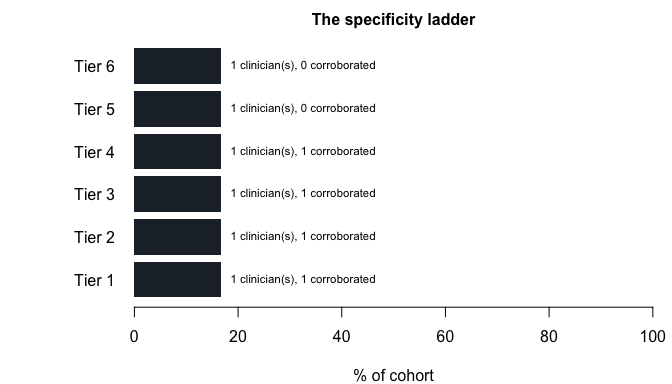

```r
tiers <- spec_audit$tiers[spec_audit$tiers$specificity_tier != "Total", ]
tiers <- tiers[order(tiers$pct_of_cohort), ]
short_tier <- sub(":.*", "", tiers$specificity_tier)

op <- par(mar = c(4, 7, 2, 1))
mid <- barplot(tiers$pct_of_cohort, names.arg = short_tier, horiz = TRUE, las = 1,
               col = "#1F2A33", border = NA, xlim = c(0, 100),
               xlab = "% of cohort", main = "The specificity ladder", cex.main = 1)
text(tiers$pct_of_cohort, mid,
     labels = paste0(tiers$n_clinicians, " clinician(s), ", tiers$n_any_corroborated, " corroborated"),
     pos = 4, cex = 0.72, xpd = TRUE)
```

```r
par(op)
```

**Why it matters:** “linked to a location” and “verified to practice there” are not the same claim, and reporting only the first one overstates how much the directory actually knows. The funnel and tier table make that gap explicit instead of letting a single “% with a practice address” number paper over it.

### Billing-Group Network Topology and Shannon Location Entropy

**The fix:** `attribute_billing_group_topology()` shifts the unit of analysis to the **billing organization** (`enrollment_id`) itself, computing Shannon location entropy $H(g) = -\sum_z p_z \ln p_z$, the effective number of practice ZIPs $N_{\text{eff}}(g) = \exp(H(g))$, and inverse-fanout specificity weights $w_{\text{info}}(g) = 1 / N_{\text{eff}}(g)$:

```r
topo <- attribute_billing_group_topology(linked_pecos)
topo$groups[, c(
  "enrollment_id", "n_clinicians", "n_unique_zip5", "n_unique_states",
  "shannon_entropy_nats", "effective_n_zip5", "location_specificity_weight",
  "group_archetype"
)]
```

```
#> # A tibble: 5 × 8
#>   enrollment_id n_clinicians n_unique_zip5 n_unique_states shannon_entropy_nats
#>   <chr>                <int>         <int>           <int>                <dbl>
#> 1 G_METRO_A                1             1               1               0
#> 2 G_METRO_B                1             1               1               0
#> 3 G_MULTISTATE             1             2               2               0.6931
#> 4 G_SOLO                   1             1               1               0
#> 5 G_SYSTEM                 1             6               1               1.792
#>   effective_n_zip5 location_specificity_weight
#>              <dbl>                       <dbl>
#> 1                1                      1
#> 2                1                      1
#> 3                2                      0.5
#> 4                1                      1
#> 5                6                      0.1667
#>   group_archetype
#>   <ord>
#> 1 1. Single-Site Practice (1 ZIP5, 1 State)
#> 2 1. Single-Site Practice (1 ZIP5, 1 State)
#> 3 5. Multi-State System / National Aggregator (>=2 States)
#> 4 1. Single-Site Practice (1 ZIP5, 1 State)
#> 5 3. Intrastate Regional Group (2-20 ZIP5s across >=2 SCF3s, 1 State)
```

```r
topo$archetype_summary
```

```
#> # A tibble: 5 × 6
#>   group_archetype                                                     n_groups
#>   <chr>                                                                  <int>
#> 1 1. Single-Site Practice (1 ZIP5, 1 State)                                  3
#> 2 2. Local Multi-Site Group (2-5 ZIP5s, 1 SCF3, 1 State)                     0
#> 3 3. Intrastate Regional Group (2-20 ZIP5s across >=2 SCF3s, 1 State)        1
#> 4 4. Large Intrastate Health System (>20 ZIP5s, 1 State)                     0
#> 5 5. Multi-State System / National Aggregator (>=2 States)                   1
#>   pct_of_groups n_clinician_links pct_of_clinician_links median_unique_zip5
#>           <dbl>             <int>                  <dbl>              <dbl>
#> 1            60                 3                     60                  1
#> 2             0                 0                      0                 NA
#> 3            20                 1                     20                  6
#> 4             0                 0                      0                 NA
#> 5            20                 1                     20                  2
```

```r
topo$clinician_weights[, c(
  "id", "n_groups", "max_group_specificity_weight",
  "best_enrollment_id", "best_group_archetype"
)]
```

```
#> # A tibble: 4 × 5
#>   id    n_groups max_group_specificity_weight best_enrollment_id
#>   <chr>    <int>                        <dbl> <chr>
#> 1 2            1                       1      G_SOLO
#> 2 3            2                       1      G_METRO_A
#> 3 4            1                       0.1667 G_SYSTEM
#> 4 5            1                       0.5    G_MULTISTATE
#>   best_group_archetype
#>   <chr>
#> 1 1. Single-Site Practice (1 ZIP5, 1 State)
#> 2 1. Single-Site Practice (1 ZIP5, 1 State)
#> 3 3. Intrastate Regional Group (2-20 ZIP5s across >=2 SCF3s, 1 State)
#> 4 5. Multi-State System / National Aggregator (>=2 States)
```

### Figure 3: where the fan-out risk actually concentrates

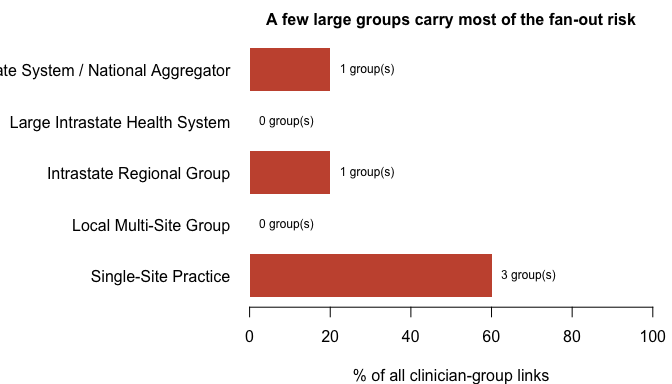

```r
arch <- topo$archetype_summary
short_arch <- sub("^[0-9]+\\.\\s*", "", sub("\\s*\\(.*\\)$", "", arch$group_archetype))

op <- par(mar = c(4, 13, 2, 1))
mid <- barplot(arch$pct_of_clinician_links, names.arg = short_arch, horiz = TRUE, las = 1,
               col = "#C8553D", border = NA, xlim = c(0, 100),
               xlab = "% of all clinician-group links", main = "A few large groups carry most of the fan-out risk", cex.main = 1)
text(arch$pct_of_clinician_links, mid,
     labels = paste0(arch$n_groups, " group(s)"), pos = 4, cex = 0.75, xpd = TRUE)
```

```r
par(op)
```

## Mutually Exclusive Geographic Concordance & Continuous Spatial Distance

**The trap:** a clinician’s board license often records a mailing or residential address, not her practice address, so comparing it to a practice-address directory produces real disagreements for reasons that have nothing to do with data quality. Worse, if an audit reports separate match rates for ZIP5, 3-digit SCF, *and* mailing ZIP5 as three independent percentages, they overlap – and the three numbers printed side by side in a manuscript can sum to well over 100%, which is the kind of thing a peer reviewer catches immediately and never forgets.

### Hierarchical ZIP5 / SCF3 / Mailing-ZIP Concordance

**The fix:** `attribute_geographic_concordance()` enforces a strictly mutually exclusive 5-category hierarchy guaranteed to sum to exactly `100.0%`, while still reporting the overlapping marginal indicators separately for readers who want them:

```r
dir_addresses <- data.frame(
  npi = as.character(1:5),
  year = 2026L,
  practice_zip5 = c("80204", "80204", "80204", "80204", "80204"),
  mailing_zip5  = c("80204", "80206", "80301", "80204", "80204")
)
board_addresses <- data.frame(
  npi = as.character(1:5),
  year = 2026L,
  reference_zip5 = c("80204", "80206", "80301", "80210", "98101")
)

geo_conc <- attribute_geographic_concordance(dir_addresses, board_addresses)
geo_conc$mutually_exclusive[, c("concordance_category", "n", "pct", "ci_low", "ci_high")]
```

```
#> # A tibble: 6 × 5
#>   concordance_category
#>   <chr>
#> 1 1. Exact Practice ZIP5 Match
#> 2 2. Differs from Practice ZIP5, Matches Mailing ZIP5 (Same 3-Digit SCF)
#> 3 3. Differs from Practice ZIP5, Matches Mailing ZIP5 (Different 3-Digit SCF)
#> 4 4. Same 3-Digit SCF Area Only (No Practice or Mailing ZIP5 Match)
#> 5 5. Unattributed ZIP5 Discordance
#> 6 Total
#>       n   pct ci_low ci_high
#>   <int> <dbl>  <dbl>   <dbl>
#> 1     1    20    3.6    62.4
#> 2     1    20    3.6    62.4
#> 3     1    20    3.6    62.4
#> 4     1    20    3.6    62.4
#> 5     1    20    3.6    62.4
#> 6     5   100  100     100
```

```r
geo_conc$marginal_indicators[, c("indicator", "n", "pct")]
```

```
#> # A tibble: 4 × 3
#>   indicator                              n   pct
#>   <chr>                              <int> <dbl>
#> 1 any_same_scf3                          3    60
#> 2 same_scf3_diff_practice_zip5           2    40
#> 3 diff_practice_matches_mailing_zip5     2    40
#> 4 matches_practice_or_mailing_zip5       3    60
```

### Figure 4: one hundred percent, no double-counting

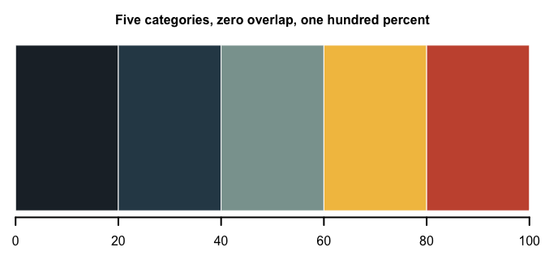

```r
me <- geo_conc$mutually_exclusive[geo_conc$mutually_exclusive$concordance_category != "Total", ]
short_cat <- sub("^[0-9]+\\.\\s*", "", me$concordance_category)
cat_cols <- c("#1F2A33", "#2E4756", "#8AA29E", "#F2C14E", "#C8553D")

tab <- matrix(me$pct, ncol = 1, dimnames = list(short_cat, "all clinicians"))
op <- par(mar = c(3, 1, 2.5, 1))
barplot(tab, horiz = TRUE, col = cat_cols, border = "white", lwd = 2,
        xlim = c(0, 100), yaxt = "n", xlab = "% of compared clinicians (sums to 100%)",
        main = "Five categories, zero overlap, one hundred percent", cex.main = 1,
        legend.text = short_cat, args.legend = list(x = "bottom", bty = "n", cex = 0.68, ncol = 2,
                                                      inset = c(0, -0.55), xpd = TRUE))
```

```r
par(op)
```

**Why it matters:** three overlapping marginal percentages invite a reader to add them up and conclude the audit double-counts. One mutually exclusive bar that visibly sums to 100% forecloses that reading entirely – and the marginal indicators are still there, just clearly labeled as overlapping rather than disguised as independent.

### Continuous Haversine Distance and Commute-Shed Bands

**The fix:** collapsing everything to “same ZIP or not” throws away real information – two suites 300 meters apart on the same hospital campus and two addresses 1,500 miles apart both read as “discordant.” `attribute_spatial_distance()` measures continuous geodesic Haversine distance (`distance_km` and `distance_miles`) and classifies pairs into 5 mutually exclusive commute-shed bands:

```r
dir_coords <- data.frame(
  npi = as.character(1:5),
  year = 2026L,
  practice_zip5 = c("80204", "80204", "80204", "80204", "80204"),
  lat = rep(39.7392, 5),
  lon = rep(-105.0186, 5)
)
ref_coords <- data.frame(
  npi = as.character(1:5),
  year = 2026L,
  reference_zip5 = c("80204", "80203", "80012", "80525", "98101"),
  lat = c(39.7392, 39.7310, 39.7000, 40.5500, 47.6062),
  lon = c(-105.0186, -104.9800, -104.8300, -105.0700, -122.3321)
)

sp_dist <- attribute_spatial_distance(
  dir_coords, ref_coords,
  dir_lat_col = "lat", dir_lon_col = "lon",
  ref_lat_col = "lat", ref_lon_col = "lon"
)
sp_dist$band_summary[, c("spatial_band", "n", "pct")]
```

```
#> # A tibble: 6 × 3
#>   spatial_band                                                 n   pct
#>   <chr>                                                    <int> <dbl>
#> 1 1. Exact Co-Location (<1 km or Exact ZIP5)                   1    20
#> 2 2. Same Neighborhood / Hospital Campus (1 to <5 km)          1    20
#> 3 3. Same Metro Commute Shed (5 to <25 km)                     1    20
#> 4 4. Regional Satellite / Extended Commute (25 to <100 km)     1    20
#> 5 5. Long-Distance / Cross-Market Discordance (>=100 km)       1    20
#> 6 Total                                                        5   100
```

```r
sp_dist$distance_distribution
```

```
#> # A tibble: 2 × 11
#>   subset                    n mean_km sd_km median_km p25_km p75_km p90_km
#>   <chr>                 <int>   <dbl> <dbl>     <dbl>  <dbl>  <dbl>  <dbl>
#> 1 all_compared_pairs        5   349.8 721.5     16.71   3.42  90.26  1019.
#> 2 zip5_discordant_pairs     4   437.3 801.9     53.49  13.39 477.4   1174.
#>   max_km median_miles mean_miles
#>    <dbl>        <dbl>      <dbl>
#> 1  1639.        10.38      217.4
#> 2  1639.        33.24      271.7
```

### Figure 5: from “mismatch” to “how far, exactly”

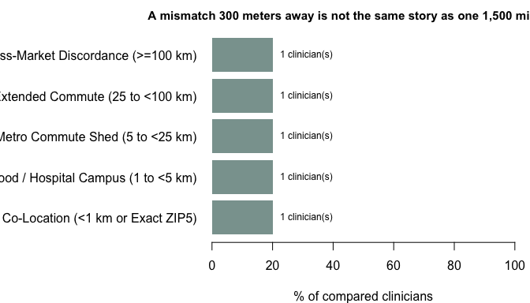

```r
bands <- sp_dist$band_summary[sp_dist$band_summary$spatial_band != "Total", ]
short_band <- sub("^[0-9]+\\.\\s*", "", bands$spatial_band)

op <- par(mar = c(4, 14, 2, 1))
mid <- barplot(bands$pct, names.arg = short_band, horiz = TRUE, las = 1,
               col = "#8AA29E", border = NA, xlim = c(0, 100),
               xlab = "% of compared clinicians", main = "A mismatch 300 meters away is not the same story as one 1,500 miles away", cex.main = 0.95)
text(bands$pct, mid, labels = paste0(bands$n, " clinician(s)"), pos = 4, cex = 0.75, xpd = TRUE)
```

```r
par(op)
```

## Multi-Attribute Inconsistency (OIG Table 4) & Hierarchical Truth Fusion

### Multi-Attribute OIG Table 4 with Composite Inconsistency Rows

**The fix:** `attribute_inconsistency_table()` evaluates set agreement across multiple attributes at once and computes the composite `"any_variable_inconsistent_union"` and `"any_variable_inconsistent_complete_case"` rows that an OIG-style Table 4 requires:

```r
src_a <- data.frame(
  npi = as.character(1:4), year = 2024L,
  practice_zip5 = c("80204", "80204", "80204", "80204"),
  state = c("CO", "CO", "CO", "CO"),
  credential = c("CNM", "CNM", "CNM", "CNM")
)
src_b <- data.frame(
  npi = as.character(1:4), year = 2024L,
  practice_zip5 = c("80204", "80301", "80204", "98101"),
  state = c("CO", "CO", "NM", "WA"),
  credential = c("CNM", "CNM", "CNM", "APRN")
)

t4_out <- attribute_inconsistency_table(
  src_a, src_b,
  attributes = c("practice_zip5", "state", "credential"),
  attribute_labels = c(
    practice_zip5 = "Practice 5-Digit ZIP",
    state = "Practice State",
    credential = "Professional Credential"
  ),
  source_a_label = "nppes",
  source_b_label = "pecos"
)

t4_out$table4_summary[, c(
  "attribute_label", "n_compared",
  "n_disjoint_inconsistent", "pct_disjoint_inconsistent",
  "n_set_diff_inconsistent", "pct_set_diff_inconsistent"
)]
```

```
#> # A tibble: 5 × 6
#>   attribute_label                                                n_compared
#>   <chr>                                                               <int>
#> 1 Practice 5-Digit ZIP                                                    4
#> 2 Practice State                                                          4
#> 3 Professional Credential                                                 4
#> 4 At Least One Variable Inconsistent (Union Denominator)                  4
#> 5 At Least One Variable Inconsistent (Complete-Case Denominator)          4
#>   n_disjoint_inconsistent pct_disjoint_inconsistent n_set_diff_inconsistent
#>                     <int>                     <dbl>                   <int>
#> 1                       2                        50                       2
#> 2                       2                        50                       2
#> 3                       1                        25                       1
#> 4                       3                        75                       3
#> 5                       3                        75                       3
#>   pct_set_diff_inconsistent
#>                       <dbl>
#> 1                        50
#> 2                        50
#> 3                        25
#> 4                        75
#> 5                        75
```

### Coarse-to-Fine Hierarchical Geographic Truth Fusion

**The trap:** three sources report `80204`, `80206`, and `98101` for the same entity’s 5-digit ZIP. A flat vote sees a `1-1-1` tie and abstains – even though two of those three sources agree on `CO` at the state level, and that agreement is thrown away along with the tie.

**The fix:** `attribute_hierarchical_truth_fusion()` resolves consensus from coarsest to finest grain (`state -> scf3 -> zip5`) while enforcing parent-child tree consistency, so it answers with the finest grain the evidence actually supports instead of abstaining outright:

```r
hf_s1 <- data.frame(
  npi = c("1", "2", "3", "4"), year = 2026L,
  state = c("CO", "CO", "CO", "CO"),
  zip5 = c("80204", "80204", "80204", "80204")
)
hf_s2 <- data.frame(
  npi = c("1", "2", "3", "4"), year = 2026L,
  state = c("CO", "CO", "CO", "NY"),
  zip5 = c("80204", "80206", "80301", "10001")
)
hf_s3 <- data.frame(
  npi = c("1", "2", "3", "4"), year = 2026L,
  state = c("CO", "WA", "WY", "CA"),
  zip5 = c("80204", "98101", "82001", "90210")
)

hf_res <- attribute_hierarchical_truth_fusion(
  list(nppes = hf_s1, pecos = hf_s2, tmsis = hf_s3)
)
hf_res$entities[, c(
  "id", "fused_state", "fused_scf3", "fused_zip5",
  "finest_resolved_grain", "finest_resolved_value"
)]
```

```
#> # A tibble: 4 × 6
#>   id    fused_state fused_scf3 fused_zip5 finest_resolved_grain
#>   <chr> <chr>       <chr>      <chr>      <chr>
#> 1 1     CO          802        80204      zip5
#> 2 2     CO          802        <NA>       scf3
#> 3 3     CO          <NA>       <NA>       state
#> 4 4     <NA>        <NA>       <NA>       unresolved
#>   finest_resolved_value
#>   <chr>
#> 1 80204
#> 2 802
#> 3 CO
#> 4 <NA>
```

```r
hf_res$resolution_summary
```

```
#> # A tibble: 4 × 7
#>   grain      depth n_entities n_resolved_exact_at_grain pct_resolved_exact
#>   <chr>      <int>      <int>                     <int>              <dbl>
#> 1 state          1          4                         1                 25
#> 2 scf3           2          4                         1                 25
#> 3 zip5           3          4                         1                 25
#> 4 unresolved     0          4                         1                 25
#>   n_resolved_at_or_finer pct_resolved_at_or_finer
#>                    <int>                    <dbl>
#> 1                      3                       75
#> 2                      2                       50
#> 3                      1                       25
#> 4                      1                       25
```

## Longitudinal Disagreement Trajectories & Mover/Stayer Markov Regimes

### Six-Way Mutually Exclusive Disagreement Trajectory Decomposition

**The fix:** `attribute_disagreement_trajectories()` partitions every base-year disagreement into 6 mutually exclusive longitudinal outcomes – including bidirectional cross-adoption, convergence on a brand-new third value, uncensored persistent discordance, and right-censored loss to follow-up:

```r
panel_a <- data.frame(
  npi = c("1", "1", "2", "2", "3", "3", "4", "4", "5", "5", "6"),
  year = c(2019L, 2026L, 2019L, 2026L, 2019L, 2026L, 2019L, 2026L, 2019L, 2026L, 2019L),
  zip5 = c("80204", "80204", "80204", "80301", "80204", "80301",
           "80204", "98101", "80204", "80204", "80204")
)
panel_b <- data.frame(
  npi = c("1", "1", "2", "2", "3", "3", "4", "4", "5", "5", "6"),
  year = c(2019L, 2026L, 2019L, 2026L, 2019L, 2026L, 2019L, 2026L, 2019L, 2026L, 2019L),
  zip5 = c("80301", "80204", "80301", "80301", "80301", "80204",
           "80301", "98101", "80301", "80301", "80301")
)

traj_out <- attribute_disagreement_trajectories(
  panel_a, panel_b,
  attribute = "zip5",
  base_year = 2019L,
  max_panel_year = 2026L,
  source_a_label = "PECOS",
  source_b_label = "NPPES"
)

traj_out$summary[, c("trajectory_code", "n", "pct", "median_years_to_resolution")]
```

```
#> # A tibble: 8 × 4
#>   trajectory_code                      n    pct median_years_to_resolution
#>   <chr>                            <int>  <dbl>                      <dbl>
#> 1 b_only_adopted_a_base                1  16.67                          7
#> 2 a_only_adopted_b_base                1  16.67                          7
#> 3 bidirectional_cross_adoption         1  16.67                          7
#> 4 converged_new_third_value            1  16.67                          7
#> 5 unresolved_uncensored_persistent     1  16.67                         NA
#> 6 unresolved_right_censored            1  16.67                         NA
#> 7 resolved_total                       4  66.67                          7
#> 8 total                                6 100                            NA
```

```r
cat(strwrap(traj_out$prose, width = 78), sep = "\n")
```

```
#> Among 6 identifiers where PECOS and NPPES disagreed on zip5 in 2019, a
#> mutually exclusive longitudinal trajectory decomposition through 2026 showed
#> that 4 (66.7%) resolved during follow-up: 1 (16.7%) via NPPES adopting
#> PECOS's 2019 value alone, 1 (16.7%) via PECOS adopting NPPES's 2019 value
#> alone, 1 (16.7%) via bidirectional cross-adoption, and 1 (16.7%) via
#> convergence on a new third value. The remaining 2 (33.3%) never converged
#> during the observation window, comprising 1 (16.7%) with uncensored
#> persistent discordance observed through 2026 and 1 (16.7%) right-censored
#> prior to 2026.
```

**Why it matters:** “the two sources disagreed in 2019” is a snapshot. Whether that disagreement resolved by PECOS adopting NPPES’s value, the reverse, both converging on a third address, or simply persisting for seven years unresolved are completely different stories about which source is trustworthy going forward – and a cross-sectional comparison alone cannot distinguish any of them.

### Mover/Stayer Mobility Typology and Contiguous-Border Markov Transitions

**The trap:** a clinician whose state flips between NY and NJ every year is not “moving” in any meaningful sense – she’s commuting across the Hudson. A clinician who goes CO $\to$ WY $\to$ UT $\to$ AZ over four years is doing something very different again. Lumping both into a single “state changed” flag erases exactly the distinction an audit needs.

**The fix:** `attribute_mover_stayer_transition_matrix()` classifies multi-year clinician trajectories into 5 mutually exclusive mobility regimes and flags whether transitions cross contiguous US state borders:

```r
state_panel <- data.frame(
  npi = c(rep("1", 4), rep("2", 4), rep("3", 4), rep("4", 4), rep("5", 4)),
  year = rep(2021:2024, 5),
  state = c(
    "CO", "CO", "CO", "CO", # 1. Strict Single-State Stayer
    "KS", "KS", "KS", "KS", # 2. Concurrent Multi-State Stayer (KS + MO in T-MSIS)
    "CO", "CO", "WY", "WY", # 3. One-Time Permanent Mover (CO -> WY)
    "NY", "NJ", "NY", "NJ", # 4. Alternating / Return Border Commuter (NY <-> NJ)
    "CO", "WY", "UT", "AZ"  # 5. Multi-State Serial Mover / Traveler
  )
)
tmsis_concurrent <- data.frame(
  npi = c("2", "2"),
  year = c(2022L, 2022L),
  state = c("KS", "MO")
)

markov_out <- attribute_mover_stayer_transition_matrix(
  state_panel,
  concurrent_source = tmsis_concurrent
)
markov_out$regime_summary[, c("mobility_regime", "n", "pct", "pct_with_contiguous_border_move")]
```

```
#> # A tibble: 6 × 4
#>   mobility_regime
#>   <chr>
#> 1 1. Strict Single-State Stayer
#> 2 2. Concurrent Multi-State Stayer (1 Primary State, >=2 Concurrent States)
#> 3 3. One-Time Permanent Mover (A -> B)
#> 4 4. Alternating / Return Commuter (A -> B -> A)
#> 5 5. Multi-State Serial Mover / Traveler (>=3 Primary States)
#> 6 Total
#>       n   pct pct_with_contiguous_border_move
#>   <int> <dbl>                           <dbl>
#> 1     1    20                               0
#> 2     1    20                               0
#> 3     1    20                             100
#> 4     1    20                             100
#> 5     1    20                             100
#> 6     5   100                              60
```

```r
markov_out$behavioral_markov
```

```
#> # A tibble: 5 × 5
#>   transition_type            n_transitions n_total_steps pct_of_all_steps
#>   <chr>                              <int>         <int>            <dbl>
#> 1 stay_same_state                        8            15            53.33
#> 2 move_to_new_state                      5            15            33.33
#> 3 return_to_prior_state                  2            15            13.33
#> 4 any_move_contiguous_border             7            15            46.67
#> 5 any_move_non_contiguous                0            15             0
#>   pct_of_moves
#>          <dbl>
#> 1        NA
#> 2        71.43
#> 3        28.57
#> 4       100
#> 5         0
```

### Figure 6: five very different reasons a “move” shows up in the data

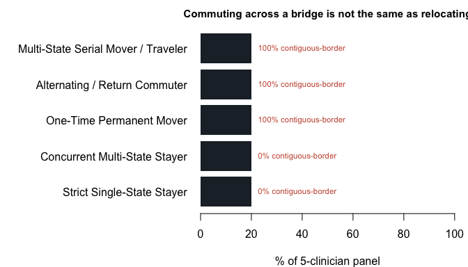

```r
reg <- markov_out$regime_summary[markov_out$regime_summary$mobility_regime != "Total", ]
short_reg <- sub("^[0-9]+\\.\\s*", "", sub("\\s*\\(.*\\)$", "", reg$mobility_regime))

op <- par(mar = c(4, 15, 2, 1))
mid <- barplot(reg$pct, names.arg = short_reg, horiz = TRUE, las = 1,
               col = "#1F2A33", border = NA, xlim = c(0, 100),
               xlab = "% of 5-clinician panel", main = "Commuting across a bridge is not the same as relocating", cex.main = 0.95)
border_pct <- ifelse(is.na(reg$pct_with_contiguous_border_move), "--", paste0(reg$pct_with_contiguous_border_move, "%"))
text(reg$pct, mid, labels = paste0(border_pct, " contiguous-border"), pos = 4, cex = 0.72, xpd = TRUE, col = "#C8553D")
```

```r
par(op)
```

**Why it matters:** the “Alternating / Return Commuter” regime is the NY/NJ clinician, correctly separated from the “One-Time Permanent Mover” and the “Multi-State Serial Mover.” Treating all three as interchangeable “state changed” events would make an audit’s turnover rate meaningless – it would mix genuine relocations with a clinician who simply crosses a river to get to work.

## Certification Lifecycle vs. NPI Enumeration & Verification Sample Design

### Separating Certification Lapse from NPI Deactivation and Post-Mortem Persistence

**The trap:** an active NPI in `NPPES` is an *enumeration* identifier, not a professional certification. A clinician’s board license can lapse, retire, or even be revoked while her NPI quietly stays active in NPPES – or the reverse: her certification stays current while an administrative deactivation sits unprocessed. Worse, a deceased clinician can keep showing up in downstream billing and enrollment panels for years after death if nobody cross-checks the certifying board’s record against enumeration status.

**The fix:** `attribute_enumeration_lifecycle()` separates certification/licensure status (`active`, `lapsed_or_retired`, `deceased`, `revoked_or_suspended`) from NPI enumeration status (`active_nppes` vs. `confirmed_deactivated`), audits deceased clinicians by linkage tier, and checks downstream panels for post-event “ghost” activity:

```r
cert_roster <- data.frame(
  npi = c("1", "2", "3", "4", "5"),
  cert_status = c("ACTIVE", "EXPIRED", "RETIRED", "DECEASED", "DECEASED"),
  match_tier = c("Tier 1", "Tier 1", "Tier 1", "Tier 1", "Tier 2"),
  event_year = c(NA, 2020L, 2021L, 2018L, 2019L)
)
active_nppes <- data.frame(npi = c("1", "2", "3", "5"))
deact_nppes <- data.frame(npi = "4", deactivation_date = "2018-09-01")
downstream_panels <- list(
  pecos = data.frame(npi = c("1", "2"), year = c(2024L, 2024L)),
  tmsis = data.frame(npi = c("1", "3", "5"), year = c(2024L, 2020L, 2022L))
)

life_out <- attribute_enumeration_lifecycle(
  cert_roster,
  active_enumeration = active_nppes,
  deactivated_enumeration = deact_nppes,
  activity_panels = downstream_panels,
  event_year_col = "event_year"
)

life_out$matrix_summary[, c(
  "lifecycle_status", "npi_enumeration_status", "n", "pct", "n_post_event_downstream"
)]
```

```
#> # A tibble: 4 × 5
#>   lifecycle_status  npi_enumeration_status     n   pct n_post_event_downstream
#>   <chr>             <chr>                  <int> <dbl>                   <int>
#> 1 active            active_nppes               1    20                       0
#> 2 deceased          active_nppes               1    20                       1
#> 3 deceased          confirmed_deactivated      1    20                       0
#> 4 lapsed_or_retired active_nppes               2    40                       1
```

```r
life_out$deceased_audit
```

```
#> # A tibble: 3 × 7
#>   match_tier n_deceased n_confirmed_deactivated n_still_active_nppes
#>   <chr>           <int>                   <int>                <int>
#> 1 Tier 1              1                       1                    0
#> 2 Tier 2              1                       0                    1
#> 3 Overall             2                       1                    1
#>   pct_still_active_nppes n_any_downstream_activity
#>                    <dbl>                     <int>
#> 1                      0                         0
#> 2                    100                         1
#> 3                     50                         1
#>   n_post_event_downstream_activity
#>                              <int>
#> 1                                0
#> 2                                1
#> 3                                1
```

NPI 5 died in 2019 but is a `Tier 2` (weaker) linkage match, and still appears in the T-MSIS panel in 2022 – three years of post-mortem billing activity that only surfaces because this function cross-checks the death date against downstream panels instead of trusting either source alone.

### Designing a Stratified Independent Verification Sample

**The trap:** administrative concordance is not the same claim as clinically verified accuracy. Moving from one to the other means calling people – and calling everyone at the same rate wastes money on clinicians who are already well-corroborated while under-sampling exactly the discordant, unlinked cases an audit most needs to resolve.

**The fix:** `design_verification_sample()` computes finite-population- corrected Neyman, cost-optimal, proportional, or equal allocations across specificity tiers, inflates fielded sample sizes for expected nonresponse, and hands the result directly to `stratified_listing_sample()`:

```r
sampling_frame <- data.frame(
  npi = sprintf("NPI%04d", 1:1000),
  stratum = c(
    rep("tier1_pinpoint_concordant", 600),
    rep("tier2_multisite_group", 300),
    rep("tier3_discordant_unlinked", 100)
  )
)

sample_plan <- design_verification_sample(
  sampling_frame,
  allocation_method = "cost_optimal",
  target_moe = 0.04,
  prior_p = c(
    tier1_pinpoint_concordant = 0.90,
    tier2_multisite_group = 0.60,
    tier3_discordant_unlinked = 0.25
  ),
  unit_cost = c(
    tier1_pinpoint_concordant = 1.0,
    tier2_multisite_group = 2.0,
    tier3_discordant_unlinked = 3.5
  ),
  response_rate = 0.85
)

sample_plan$strata[, c(
  "stratum", "pop_N", "prior_p", "unit_cost",
  "n_complete", "n_fielded", "design_weight", "stratum_moe"
)]
```

```
#> # A tibble: 3 × 8
#>   stratum                   pop_N prior_p unit_cost n_complete n_fielded
#>   <chr>                     <int>   <dbl>     <dbl>      <int>     <int>
#> 1 tier1_pinpoint_concordant   600    0.9        1          151       178
#> 2 tier2_multisite_group       300    0.6        2           87       103
#> 3 tier3_discordant_unlinked   100    0.25       3.5         20        24
#>   design_weight stratum_moe
#>           <dbl>       <dbl>
#> 1          3.37      0.0414
#> 2          2.91      0.0869
#> 3          4.17      0.1706
```

```r
sample_plan$design_summary[, c(
  "allocation_method", "n_complete_total", "n_fielded_total",
  "expected_overall_p", "expected_moe", "design_effect_deff", "expected_manski_width"
)]
```

```
#> # A tibble: 1 × 7
#>   allocation_method n_complete_total n_fielded_total expected_overall_p
#>   <chr>                        <int>           <int>              <dbl>
#> 1 cost_optimal                   258             305              0.745
#>   expected_moe design_effect_deff expected_manski_width
#>          <dbl>              <dbl>                 <dbl>
#> 1       0.0399              0.757                  0.15
```

```r
drawn_sample <- stratified_listing_sample(
  sampling_frame,
  allocation = sample_plan$allocation_vector,
  seed = 20261111L
)
nrow(drawn_sample)
```

```
#> [1] 305
```

### Figure 7: paying for precision where it’s actually uncertain

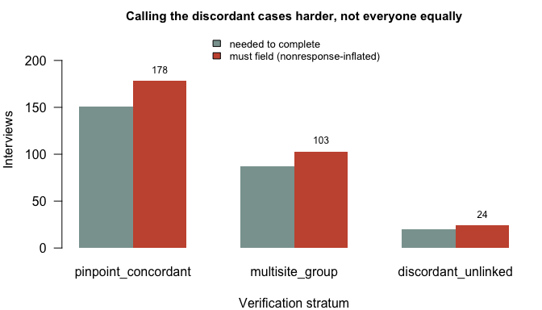

```r
strata <- sample_plan$strata
m <- rbind(strata$n_complete, strata$n_fielded)
colnames(m) <- sub("^tier[0-9]_", "", strata$stratum)

op <- par(mar = c(4, 4, 2, 1))
mid <- barplot(m, beside = TRUE, col = c("#8AA29E", "#C8553D"), border = NA,
               ylim = c(0, max(m) * 1.3), las = 1,
               xlab = "Verification stratum", ylab = "Interviews",
               main = "Calling the discordant cases harder, not everyone equally", cex.main = 0.95,
               legend.text = c("needed to complete", "must field (nonresponse-inflated)"),
               args.legend = list(x = "top", bty = "n", cex = 0.8))
text(mid[2, ], m[2, ], labels = m[2, ], pos = 3, cex = 0.75)
```

```r
par(op)
```

**Why it matters:** the discordant-unlinked stratum is only 10% of the population but, under cost-optimal allocation with its lower prior accuracy and higher unit cost, draws a share of the verification budget far out of proportion to its size – exactly where the audit’s final accuracy number is least certain and most worth the extra calls.

## Integrated OIG Prose/HTML Reporting & Version Reconciliation

### Generating OIG Prose and HTML with Clinician-Level Location Specificity

**The fix:** `attribute_oig_audit_prose()` and `attribute_oig_audit_html()` accept `location_specificity` straight from `attribute_location_specificity()` and embed the plain-English clinician-level linkage summary plus Appendix A2 (the 4-stage evidence funnel and 6-tier specificity table) automatically – so the manuscript prose and the underlying audit tables can never drift apart from each other:

```r
rp_2019 <- data.frame(
  id = rep(as.character(1:6), 2),
  year = 2019L,
  source = rep(c("nppes", "pecos"), each = 6),
  attribute = "practice_zip5",
  record_present = c(rep(TRUE, 6), rep(TRUE, 5), FALSE),
  field_status = c(rep("populated", 6), rep("populated", 5), "absent_from_declared_extract")
)

set_ag_2019 <- attribute_set_agreement(
  list(
    nppes = data.frame(npi = as.character(1:5), year = 2019L, practice_zip5 = c("80204", "80206", "80301", "80204", "99999")),
    pecos = data.frame(npi = as.character(1:5), year = 2019L, practice_zip5 = c("80204", "80206", "80301", "80204", "80204"))
  ),
  attribute = "practice_zip5"
)
set_sum_2019 <- attribute_set_agreement_summary(set_ag_2019)

oig_paragraph <- attribute_oig_audit_prose(
  record_presence = rp_2019,
  set_agreement_summary = set_sum_2019,
  year = 2019L,
  source_a = "nppes",
  source_b = "pecos",
  attribute = "practice_zip5",
  attribute_label = "practice ZIP codes",
  linkage = linked_pecos,
  provider_noun = "nurse-midwife",
  location_specificity = spec_audit
)
cat(strwrap(oig_paragraph, width = 78), sep = "\n")
```

```
#> In 2019, NPPES and PECOS contained 6 and 5 nurse-midwife records,
#> respectively, within the declared study frame. Among records present with the
#> field available in each source, practice ZIP codes were populated in 100.0%
#> and 100.0%, respectively. Among 5 comparable nurse-midwives, at least one
#> value matched in 80.0%, whereas the complete reported value sets agreed in
#> 80.0%. Enrollment linkage identified 1 direct and 12 group-reassignment
#> nurse-midwife-enrollment-location associations; these administrative
#> associations did not establish clinical presence. Practice-location
#> information was directly linked to 16.7% of nurse-midwives (1 of 6), whereas
#> linking clinicians to their billing organizations identified associated
#> locations for 83.3% (5 of 6). However, these organizational addresses were
#> not independently verified as the clinicians' actual practice sites: only
#> 33.3% (2 of 6) mapped to a single pinpoint practice ZIP code, while 33.3% (2
#> of 6) were linked through large multi-site or multi-state billing
#> organizations (mean 2.8, median 2 unique ZIP codes per group-linked
#> clinician). External sources corroborated a pinpoint single-site ZIP code for
#> 2 nurse-midwives (33.3% of cohort; 100.0% of pinpoint sites), and
#> corroborated a practice ZIP code across all reference sources for 4 (66.7%);
#> cross-source agreement among administrative registries is not independent
#> clinical verification. Cross-source disagreement was not classified as
#> verified inaccuracy.
```

```r
oig_html <- attribute_oig_audit_html(
  record_presence = rp_2019,
  set_agreement_summary = set_sum_2019,
  year = 2019L,
  source_a = "nppes",
  source_b = "pecos",
  attribute = "practice_zip5",
  attribute_label = "practice ZIP codes",
  linkage = linked_pecos,
  provider_noun = "nurse-midwife",
  location_specificity = spec_audit
)
grepl("Appendix A2: Clinician-Level Location Specificity", oig_html, fixed = TRUE)
```

```
#> [1] TRUE
```

### Automated Accounting-Identity Validation & Audit Reconciliation Log

**The trap:** manuscript numbers change between drafts for good reasons all the time – a definition gets fixed, a data vintage gets corrected – but if that change isn’t logged anywhere, a reviewer (or your own future self) has no way to tell a legitimate correction from an unexplained drift in the numbers.

**The fix:** `attribute_audit_diff()` verifies that every mutually exclusive table in this vignette (`geo_conc$mutually_exclusive`, `spec_audit$tiers`, `traj_out$summary`, `markov_out$regime_summary`) still sums to `100.0%`, and generates a structured, reasoned log comparing baseline and revised manuscript metrics side by side:

```r
baseline_draft <- c(
  pecos_clinician_linkage_pct = 95.69,
  board_concordance_sum_pct = 103.58,
  medicare_2018_coverage_pct = 22.71,
  trajectory_accounted_pct = 100.00
)

revised_draft <- c(
  pecos_clinician_linkage_pct = 95.69,
  board_concordance_sum_pct = 100.00,
  medicare_2018_coverage_pct = 46.84,
  trajectory_accounted_pct = 100.00
)

reconciliation_reasons <- c(
  board_concordance_sum_pct = "Replaced overlapping marginal ZIP3/mailing counts with 5-way mutually exclusive hierarchy.",
  medicare_2018_coverage_pct = "Merged 2018 DAC historical release with 2018 PECOS snapshot to match 2019/2021 composite definition."
)

reconcile_out <- attribute_audit_diff(
  baseline = baseline_draft,
  revised = revised_draft,
  partitions = list(
    geographic_concordance = geo_conc$mutually_exclusive,
    location_specificity = spec_audit$tiers,
    disagreement_trajectories = traj_out$summary,
    mobility_regimes = markov_out$regime_summary
  ),
  reasons = reconciliation_reasons
)

reconcile_out$partition_checks
```

```
#> # A tibble: 4 × 7
#>   partition_name            n_categories sum_n expected_n sum_pct
#>   <chr>                            <int> <int>      <int>   <dbl>
#> 1 geographic_concordance               5     5          5   100
#> 2 location_specificity                 6     6          6   100.0
#> 3 disagreement_trajectories            6     6          6   100.0
#> 4 mobility_regimes                     5     5          5   100
#>   pct_deviation_from_100 identity_valid
#>                    <dbl> <lgl>
#> 1                   0    TRUE
#> 2                   0.02 TRUE
#> 3                   0.02 TRUE
#> 4                   0    TRUE
```

```r
reconcile_out$diff_table[, c("metric_id", "old_value", "new_value", "raw_delta", "status")]
```

```
#> # A tibble: 4 × 5
#>   metric_id                   old_value new_value raw_delta status
#>   <chr>                           <dbl>     <dbl>     <dbl> <chr>
#> 1 pecos_clinician_linkage_pct     95.69     95.69      0    unchanged
#> 2 board_concordance_sum_pct      103.6     100        -3.58 reconciled_change
#> 3 medicare_2018_coverage_pct      22.71     46.84     24.13 reconciled_change
#> 4 trajectory_accounted_pct       100       100         0    unchanged
```

```r
cat(reconcile_out$markdown_table, sep = "\n")
```

```
#> | Metric | Baseline | Revised | Delta | Status | Reconciliation Reason |
#> | :--- | ---: | ---: | ---: | :--- | :--- |
#> | `pecos_clinician_linkage_pct` | 95.69 | 95.69 | 0 | unchanged | No change |
#> | `board_concordance_sum_pct` | 103.6 | 100 | -3.58 | reconciled_change | Replaced overlapping marginal ZIP3/mailing counts with 5-way mutually exclusive hierarchy. |
#> | `medicare_2018_coverage_pct` | 22.71 | 46.84 | +24.13 | reconciled_change | Merged 2018 DAC historical release with 2018 PECOS snapshot to match 2019/2021 composite definition. |
#> | `trajectory_accounted_pct` | 100 | 100 | 0 | unchanged | No change |
```

Notice `board_concordance_sum_pct`: the baseline draft’s `103.58%` is exactly the kind of overlapping-marginal arithmetic error Figure 4, above, exists to prevent, and the revised draft’s clean `100.00%` is what replacing it with the mutually exclusive hierarchy actually buys. `medicare_2018_coverage_pct` is the missing-sub-feed story from earlier in this vignette, seen from a different angle – the jump from `22.71%` to `46.84%` is not a data problem, it’s a definition fix, and the reconciliation log says so in plain words instead of leaving a reviewer to wonder.

**Why it matters:** every number in this vignette ultimately has to survive contact with a skeptical reader. The reconciliation log is what lets you say, with a straight face, exactly why a number changed between two drafts of the same manuscript – and prove, mechanically, that the tables behind it still add up.

## What this vignette does and doesn’t establish

None of the functions above establish ground truth on their own. A clinician’s directory listing can pass every check in this vignette – correctly formatted, pinned to one ZIP by every corroborating source, with a clean reconciliation log – and still be wrong, if the underlying practice address is simply stale in every source at once. The hierarchical truth fusion above only resolves ties among the sources it’s actually given; for genuine N-way consensus questions – how much of a *larger* group agrees, whether that agreement holds up over time, which source the group tends to converge toward – see `vignette("consensus-and-corroboration")`. The geographic and spatial concordance checks here assume the basic pairwise agreement and freshness primitives from `vignette("attribute-agreement")` already ran cleanly; this vignette picks up at the point where a flat match/no-match rate stops being enough. And the mover/stayer and disagreement-trajectory machinery above is a longitudinal complement to, not a replacement for, the lead-lag and catch-up-curve approaches in `vignette("lead-lag-staleness")` – use that vignette to ask which source is ahead; use this one to ask whether a change in state represents a permanent move or a daily commute.